# Kernel methods for regression: Exercise solutions

Course: Machine Learning II, Data Science Master (Universidad de Cantabria - UIMP).  
Lecturers: Steven Van Vaerenbergh, Ignacio Santamaria.

```python
import numpy as np
import pandas as pd
import matplotlib.pyplot as plt

# inline plots
%matplotlib inline
```

## Exercise 1: Combinations of kernels

Kernel functions can be combined in several ways to produce new kernel functions. For instance, the summation or multiplication of two kernel functions produces a new kernel function.

1. Write a function to calculate a kernel that is the multiplication of the `ExpSineSquared` kernel and a kernel of your choice (RBF, linear, poly, etc.).
2. Calculate and plot the kernel expansion $f(x) = \sum_{i=1}^n \alpha_i \kappa(x, x_i)$:
   1. Choose 4 or 5 one-dimensional "bases" $x_i$.
   2. Generate the corresponding coefficients $\alpha_i$ randomly (with a fixed random seed).
   3. Calculate and plot the kernel expansion $f(x) = \sum_{i=1}^n \alpha_i \kappa(x, x_i)$ for a range of x values that includes at least the bases.
   4. [Optional] Plot the individual basis functions corresponding to each base.

```python
from sklearn.metrics.pairwise import rbf_kernel
from sklearn.gaussian_process.kernels import ExpSineSquared

# 1. Kernel function
def my_kernel(X1, X2,gamma=1,length_scale=1,periodicity=3.1415):
    """
    Computes the linear kernel between two sets of vectors.
    Args:
        X1 - an n1xd matrix with vectors x1_1,...,x1_n1 in the rows
        X2 - an n2xd matrix with vectors x2_1,...,x2_n2 in the rows
    Returns:
        matrix of size n1xn2, K(x1_i,x2_j) in position i,j
    """

    # RBF kernel
    K1 = rbf_kernel(X1,X2,gamma=gamma)

    # ExpSineSquared kernel
    kernel2 = ExpSineSquared(length_scale=length_scale,periodicity=periodicity )
    K2 = kernel2.__call__(X1,X2)

    K = K1 * K2

    return K
```

```
Generated coefficients:
[[0.5488135 ]
 [0.71518937]
 [0.60276338]
 [0.54488318]]
```

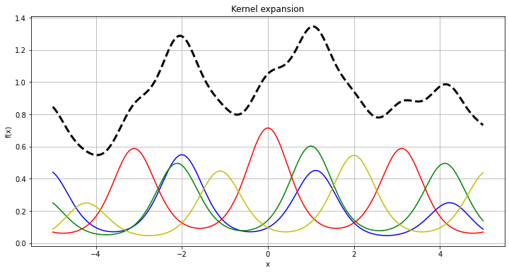

```python
# 2. Kernel expansion

gamma = 0.02
length_scale = 1
periodicity = np.pi

# 2A. Choose 4 or 5 one-dimensional "bases" xi
x_i = np.array([-2, 0, 1, 2]).reshape(-1,1)

# 2B. Generate the corresponding coefficients alpha randomly (with a fixed random seed)
np.random.seed(seed=0)
alpha_i = np.random.rand(4,1).reshape(-1,1)
print("Generated coefficients:\n{}".format(alpha_i))

# 2C. Calculate and plot the kernel expansion for a range of x values that includes at least the bases
x = np.linspace(-5,5,1000).reshape(-1,1)
K = my_kernel(x,x_i,gamma=gamma)
f = np.dot(K,alpha_i)

# 2D. Plot the individual basis functions corresponding to each base.
plt.figure(figsize=(12,6))
plt.plot(x,alpha_i[0]*K[:,0],color='b')
plt.plot(x,alpha_i[1]*K[:,1],color='r')
plt.plot(x,alpha_i[2]*K[:,2],color='g')
plt.plot(x,alpha_i[3]*K[:,3],color='y')
plt.plot(x,f,color='k',linestyle='--',linewidth=3)
plt.xlabel('x')
plt.ylabel('f(x)')
plt.grid(True)
plt.title('Kernel expansion')
plt.show()
```

## Exercise 2: Motorcycle Data

Exercise: Train both regression techniques (SVR and KRR) on the motorcycle data set. Determine the best hyperparameters by running the GridSearchCV optimization technique.

1. Learn the optimal hyperparameters.
2. Produce predictions and plot.

```python
df = pd.read_csv('data/motor.csv',delimiter=';')
```

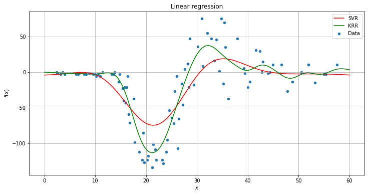

```
SVR(C=10.0, epsilon=0.05, gamma=0.01)
KernelRidge(alpha=1.0, gamma=0.1, kernel='rbf')
```

```python
from sklearn.svm import SVR
from sklearn.kernel_ridge import KernelRidge
from sklearn.model_selection import GridSearchCV

X = df.times.values.reshape(-1, 1)
y = df.accel.values

clf_svr = GridSearchCV(SVR(kernel='rbf', gamma=0.5), cv=5,
                   param_grid={"C": [1e-1, 1e0, 1e1, 1e2],
                               "epsilon": [0.05, 0.1, 0.5],
                               "gamma": np.logspace(-2, 2, 5)})

clf_krr = GridSearchCV(KernelRidge(kernel='rbf', gamma=0.5), cv=5,
                  param_grid={"alpha": [1e-1, 1e0, 0.1, 1e-2, 1e-3],
                              "gamma": np.logspace(-2, 2, 5)})

# train classifiers
clf_svr.fit(X,y)
clf_krr.fit(X,y)

# Test the regressors
X_test = np.linspace(0,60,500).reshape(-1,1)
y_pred_svr = clf_svr.predict(X_test)
y_pred_krr = clf_krr.predict(X_test)

plt.figure(figsize=(12,6))
plt.scatter(X,y,s=20,label='Data')
plt.plot(X_test,y_pred_svr,color='r',label='SVR')
plt.plot(X_test,y_pred_krr,color='g',label='KRR')
plt.title('Linear regression')
plt.xlabel('$x$')
plt.ylabel('$f(x)$')
plt.grid(True)
plt.legend()
plt.show()

print(clf_svr.best_estimator_)
print(clf_krr.best_estimator_)
```